# Data Representation general principles and pointers

w. cools

Compiled May 15, 2020

Current draft aims to introduce researchers to the key ideas in data representation that would help prepare for data analysis. Our target audience is primarily the research community at VUB / UZ Brussel, those who might apply for data analysis at ICDS in particular.  
We invite you to help improve this document by sending us feedback  
wilfried.cools@vub.be or anonymously at icds.be/consulting (right side, bottom)

# key message on data representation

In preparation of data analysis, it is wise to think carefully about how to represent data. The key ideas are listed first, and will be explained and exemplified in more detail throughout current draft.

- Represent data so that
  - you and fellow researchers understand it, now but also in future,
  - statistical algorithms understand it,
  - the gap researcher - algorithm is minimized (efficient processing)
    - allows for straightforward data manipulation, modeling, visualization.
- Table formats combine rows and columns in cells:
  - cells contain one and only one piece of information,
  - rows relate cells to a research unit, could be a patient, a mouse, a center, … ,
  - columns relate cells to a property,
  - cells offer information for specific research unit - property combinations.
- Ideally, data are TIDY, with meaning appropriately mapped into structure:
  - use observations as research unit (each row an observation),
  - use a table for each type of observations (observational unit).
- Check data by
  - eye-balling to ensure a correct and unambiguous interpretation of cell values,
  - descriptive analysis to detect anomalies from frequency tables and summaries.

# challenge

Test yourself: create a data file for the following 4 participants (assuming many more), ready for analysis.

- Enid Charles, age 43,
  - visual score 16, mathematical score 2.4,
  - suggested methods A and B,
  - performance score at first time point 101 and second time point 105.
- Gertrude Mary Cox, age 34,
  - visual score 26, mathematical score 1.4,
  - suggested methods A,
  - performance score at first time point missing and second time point 115.
- Helen Berg, age 53,
  - visual score 20, mathematical score missing,
  - suggested methods none (not A, nor B, nor C),
  - performance score at first time point 111 and second time point 110.
- Grace Wahba, age 50,
  - visual score 30, mathematical score above cut-off 10,
  - suggested methods A,
  - performance score at first time point 91 and second time point 115.

# outline

Current draft addresses data representation with the following outline:

- a challenge: it is not always clear how
- errors and inconveniences
- common difficulties and solutions

In following drafts, data manipulation, modeling and visualization are considered. Typically, all are more straightforward as data are more tidy.

# errors and inconveniences

To avoid problems and frustration in your data analysis, it may be worthwhile to consider the checklist below. It points at various issues that have been encountered in actual data at ICDS and that are easy to avoid. In general most data offered by researchers that did not attempt to do their own analysis, or at least the preliminary descriptives, is full with issues like the ones highlighted in this section.  
In summary:

- inconsistencies
- ambiguities / incompleteness
- inconveniences for either software or user

## error: inconsistent specification of cell values

When labeling or scoring properties for research units (cells), avoid typo’s, inconsistent labeling, inconsistent scoring, …

Often observed problems:

- typing errors, eg., `man` - `women` - `womem`,
- inconsistent use of capital letters, eg., `man` - `Man` - `woman`. Most statistical software is case sensitive (eg., R),
- inconsistent use of spaces (`_`), eg., `man__` - `man` - `_woman` - `woman`,
- inconsistent use of decimal indicators, eg., `4.2` - `5,3` - `5,9`. A comma is often used locally, a dot is used internationally (scientifically),
- inconsistent use of missing value indicators: `_` - NA - 99. Software differ in their default, but consistency is key !

Advice: frequency tables often suffice to detect most of these errors, or a summary for numeric values.

inconsistencies

| id | gender | score |
| --- | --- | --- |
| id1 | man | 4.2 |
| id2 | Man | 5,3 |
| id3 | man | 5,9 |
| id4 | woman | 3.1 |
| id5 | woman | 7,2 |

frequencies

| Var1 | Freq |
| --- | --- |
| man | 1 |
| Man | 1 |
| man | 1 |
| woman | 2 |

Note that the average scores is 3.65, clearly something went wrong.

## error: ambiguous and incomplete specification of cell values

When labeling or scoring properties for research units (cells), avoid ambiguity and incompleteness.

Often observed problems within cells:

- empty cells not implying missing values
  - eg., those that imply the label above,
  - eg., those implying either `missing` or `none` (no answer is different from the answer 0 or “”),
- combined numerical and non-numerical values, eg., `3.9` - `>10` (partially available information can be captured with an additional column),
- combined information within a cell, eg., `A:B`, `A:C`, `B`. (combined information can be split over additional columns, eg., colums A, B and C with values for present = yes or no).

Each cell should be fully interpretable on its own, with reference to both row and column only.

Often observed problems combining cells:

- multiple line headers, eg., a header that covers multiple rows,
- merged cells, eg., a header value that covers multiple columns.

## inconvenience: use of special characters and numbers

When labeling or scoring, or when specifying a title, avoid characters that may not be understood properly. Note that some characters call for specific operations in certain statistical software.

Often observed problems follow from using:

- special characters and spaces (eg., `$, %, #, ", ',`),
- use of names starting with numbers (eg., 1st).

Advice: keep columns with text, not part of the statistical analysis, in a separate file.

ambiguous - incomplete

| id | types | score |
| --- | --- | --- |
| id1 | A:B | 4.2 |
| id2 | A |  |
| id3 | B | 5.9 |
| id4 | A:B | >10 |
| id5 |  | 7.2 |

special characters

| id | type | score |
| --- | --- | --- |
| id1 | % use | 4.2 |
| id2 | % use | 5,3 |
| id3 | ‘run’ | 5,9 |
| id4 | ‘run’ | 3.1 |
| id5 | % use | 7,2 |

## inconvenience: complex and lengthy labels and values

When labeling variables or values, strike a balance between meaningful and simple. This is especially important when requesting help from data analysts who typically program their analysis and often do not understand your line of research. Some analysts may even prefer all values as numeric, (eg., 0 vs. 1) while others prefer short alphanumeric values (eg., male vs female).

Advice: To keep meaningful but long and complex headers, use a second line with simple headers to read in for the analysis. Maybe use `patientID` and `id1` instead of `patient_identifiers_of_first_block` and `patient_number_1`.

lengthy - complex

| patient_identifiers_of_first_block | my type | %mg rating |
| --- | --- | --- |
| patient identity number 1 | condition with extra air | 4.2 mg/s |
| patient identity number 2 | condition without extra air | 5,3 mg/s |
| patient identity number 3 | condition with extra air | 5,9 mg/s |
| patient identity number 4 | condition with extra air (stopped early) | 3.1 mg/s |
| patient identity number 5 | condition without extra air | 7,2 mg/s |

Advice: To ensure a correct interpretation, now and later, the researcher could make the following distinction,

- use numbers when values could be interpreted on a continuous scale,
- use text with clear order like `notAgree - neutral - agree`,
- use text postfixed with numbers with unclear order like `r1 - r2 - r3` for ordinal scale not to be used as continuous,
- use text for all remaining labels.

appropriate labeling

| id | type | intensity | score | rank |
| --- | --- | --- | --- | --- |
| id1 | black | low | 4.2 | rnk1 |
| id2 | black | medium | 5.3 | rnk4 |
| id3 | red | low | 5.9 | rnk3 |
| id4 | yellow | high | 3.1 | rnk3 |
| id5 | black | low | 7.2 | rnk2 |

## inconvenience: irrelevant data

When starting the analysis, or offering data to third parties, retain only the data of interest for the analysis. Store the remainder of the data in a secure place with an appropriate link.

Advice: remove

- information that could jeopardize GDPR, like names of patients (important),
- comments of participants, and other textual information not relevant for analysis
- variables that are registered insufficiently, or erroneously.
- variables that are well understood transformations from other variables
- anything that is not part of the main table, like figures and supporting tables

irrelevant

| name | score1 | score2 | sumscore | comments |
| --- | --- | --- | --- | --- |
| Enid Charles | 3 | 4 | 7 | some problems at the start |
| Gertrude Mary Cox | 3 | 3 | 6 |  |
| Helen Berg | 4 | 0 | 4 | patient showed no interest |
| Grace Wahba | 4 | 4 | 8 |  |

## error: spreadsheets for human interpretation only

Spreadsheets are convenient for representing data because their base structure is a table, with rows and columns, which you need for most statistical analysis, and because they allow for straightforward manipulations of data.  
Although spreadsheets often offer ways to do the statistical analysis, or at least the data manipulation and visualization, it is in most cases more straightforward to do all that with statistical software that is designed for that (after having mastered it).

Manually constructed spreadsheets, Excel or other, unfortunately, promote the use of implicit information rather than the required explicit information. For example, cells are left empty because it is, at least for a human, clear from the context what the value should be.

- incompleteness due to implicit information
- use of merged cells, not understood by algorithms

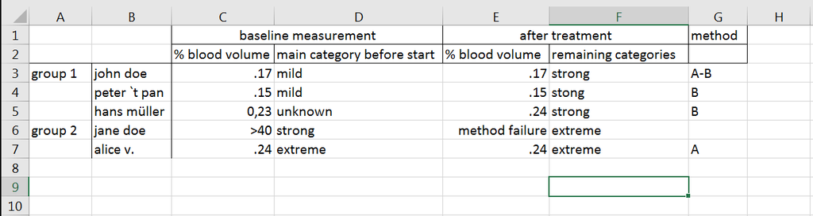

Excel showcase

Excel deserves special attention. Understandably very popular, it often does more than expected and can cause serious problems.

Often observed problems:

- inappropriate cell types, eg., values that are read in as if they are dates,
- inappropriate dimensions, eg., activated cells outside the data-frame or hidden columns,
- automatic changes of values because of inconsistencies between data and assumed data types.

Advice: A safe way to store data, once fully ready, could be a tab-delimited text file. While inconvenient to manipulate, risks for unwanted behavior are eliminated. It is straightforward to convert one into the other.

# common problems and solutions

For data analysis in most cases data is represented in one or more tables. It is repeated that:

- Tables combine rows and columns in cells:  
- with rows that relate cells within a research unit, often optimally the observation itself, - with columns that relate cells to a property, - with cells that contain values which offer one and only one piece of information, combining a research unit and a property. - Tables for different but related research units are linked by identifiers.

## a bad bad exemplary case, using R to turn it around

While it is best to avoid a bad data table from the start, when building it, if you can program then it is in many cases not impossible to convert tables into more appropriate forms.

Note: R and the R package `tidyverse` that is used here is not considered in any detail in current draft. To learn how to manipulate, visualize and model data an introduction is offered in a subsequent draft: `introduction to tidyverse`.

For example, consider this monstrous dataset, showing various features that are common in data offered for analysis.

bad bad example

| id | young | old | stat | condA_time0 | condA_time1 | condA_time2 | condB_time0 | condB_time1 | condB_time2 | subst |
| --- | --- | --- | --- | --- | --- | --- | --- | --- | --- | --- |
| person1 | TRUE | FALSE | min | NA | -10 | NA | NA | NA | NA | s1,s2 |
| person1 | TRUE | FALSE | max | NA | 20 | NA | NA | NA | NA | s1,s2 |
| person1 | TRUE | FALSE | min | NA | NA | NA | NA | NA | 0 |  |
| person1 | TRUE | FALSE | max | NA | NA | NA | NA | NA | 25 |  |
| person2 | FALSE | TRUE | min | NA | NA | NA | 5 | NA | NA | s2 |
| person2 | FALSE | TRUE | max | NA | NA | NA | 15 | NA | NA | s2 |
| person2 | FALSE | TRUE | min | NA | NA | 0 | NA | NA | NA | s1 |
| person2 | FALSE | TRUE | max | NA | NA | 10 | NA | NA | NA | s1 |

Apparently, substances (`subst`) can be `s1`, `s2`, both or none. So, having `s1,s2` is partly overlapping with `s1`, but how does the algorithm know ? Lets turn this multiple selection item into multiple columns. Apparently, young and old are two variables, which makes no sense because you are either young or old, so lets remove one of them.

```r
badExample <- tBadBad %>%
    mutate(s1=ifelse(grepl('s1', subst),T,F),s2=ifelse(grepl('s2',subst),T,F)) %>%
    select(-subst,-old)
```

split combined information

| id | young | stat | condA_time0 | condA_time1 | condA_time2 | condB_time0 | condB_time1 | condB_time2 | s1 | s2 |
| --- | --- | --- | --- | --- | --- | --- | --- | --- | --- | --- |
| person1 | TRUE | min | NA | -10 | NA | NA | NA | NA | TRUE | TRUE |
| person1 | TRUE | max | NA | 20 | NA | NA | NA | NA | TRUE | TRUE |
| person1 | TRUE | min | NA | NA | NA | NA | NA | 0 | FALSE | FALSE |
| person1 | TRUE | max | NA | NA | NA | NA | NA | 25 | FALSE | FALSE |
| person2 | FALSE | min | NA | NA | NA | 5 | NA | NA | FALSE | TRUE |
| person2 | FALSE | max | NA | NA | NA | 15 | NA | NA | FALSE | TRUE |
| person2 | FALSE | min | NA | NA | 0 | NA | NA | NA | TRUE | FALSE |
| person2 | FALSE | max | NA | NA | 10 | NA | NA | NA | TRUE | FALSE |

Apparently, various columns contain variable values. Observations are obtained under certain conditions, A or B, and at various time points, time 0, 1 or 2. Now for example condA_time1 partly overlaps with condA_time2 with its condition and condB_time1 with its time. Lets turn these columns into values first, and at the same time simply ignore the missing values.

```r
badExample <- badExample %>%
    pivot_longer(names_to="messyStuff",values_to="scores",-c(id,young,stat,s1,s2)) %>%
    filter(!is.na(scores))
```

from wide to long form

| id | young | stat | s1 | s2 | messyStuff | scores |
| --- | --- | --- | --- | --- | --- | --- |
| person1 | TRUE | min | TRUE | TRUE | condA_time1 | -10 |
| person1 | TRUE | max | TRUE | TRUE | condA_time1 | 20 |
| person1 | TRUE | min | FALSE | FALSE | condB_time2 | 0 |
| person1 | TRUE | max | FALSE | FALSE | condB_time2 | 25 |
| person2 | FALSE | min | FALSE | TRUE | condB_time0 | 5 |
| person2 | FALSE | max | FALSE | TRUE | condB_time0 | 15 |
| person2 | FALSE | min | TRUE | FALSE | condA_time2 | 0 |
| person2 | FALSE | max | TRUE | FALSE | condA_time2 | 10 |

But still, the new column still combines two types of information, condition and time, so lets split them over two columns.

```r
badExample <- badExample %>%
    separate(messyStuff,c('cond','time'))
```

separate combined information

| id | young | stat | s1 | s2 | cond | time | scores |
| --- | --- | --- | --- | --- | --- | --- | --- |
| person1 | TRUE | min | TRUE | TRUE | condA | time1 | -10 |
| person1 | TRUE | max | TRUE | TRUE | condA | time1 | 20 |
| person1 | TRUE | min | FALSE | FALSE | condB | time2 | 0 |
| person1 | TRUE | max | FALSE | FALSE | condB | time2 | 25 |
| person2 | FALSE | min | FALSE | TRUE | condB | time0 | 5 |
| person2 | FALSE | max | FALSE | TRUE | condB | time0 | 15 |
| person2 | FALSE | min | TRUE | FALSE | condA | time2 | 0 |
| person2 | FALSE | max | TRUE | FALSE | condA | time2 | 10 |

Much better. A last issue here is that the minimum and maximum could be variables and not values. No hard rules here, but often it is intuitively clear. So, lets turn these values into variables to represent two types of observation.

```r
goodExample <- badExample %>%
    pivot_wider(names_from=stat,values_from=scores)
```

from long to wide

| id | young | s1 | s2 | cond | time | min | max |
| --- | --- | --- | --- | --- | --- | --- | --- |
| person1 | TRUE | TRUE | TRUE | condA | time1 | -10 | 20 |
| person1 | TRUE | FALSE | FALSE | condB | time2 | 0 | 25 |
| person2 | FALSE | FALSE | TRUE | condB | time0 | 5 | 15 |
| person2 | FALSE | TRUE | FALSE | condA | time2 | 0 | 10 |

While not convenient here, when there are many variables it may be interesting to use this to split up the table into different tables for different research units. So, lets create a persons file and an observations file, and merge them together again afterwards.

```r
persons <- goodExample %>% select(id,young) %>% distinct()
observations <- goodExample %>% select(-young)
combinedAgain <- observations %>% full_join(persons)
```

simple persons table

| id | young |
| --- | --- |
| person1 | TRUE |
| person2 | FALSE |

simple observations table

| id | s1 | s2 | cond | time | min | max |
| --- | --- | --- | --- | --- | --- | --- |
| person1 | TRUE | TRUE | condA | time1 | -10 | 20 |
| person1 | FALSE | FALSE | condB | time2 | 0 | 25 |
| person2 | FALSE | TRUE | condB | time0 | 5 | 15 |
| person2 | TRUE | FALSE | condA | time2 | 0 | 10 |

merged again using person as identifier

| id | s1 | s2 | cond | time | min | max | young |
| --- | --- | --- | --- | --- | --- | --- | --- |
| person1 | TRUE | TRUE | condA | time1 | -10 | 20 | TRUE |
| person1 | FALSE | FALSE | condB | time2 | 0 | 25 | TRUE |
| person2 | FALSE | TRUE | condB | time0 | 5 | 15 | FALSE |
| person2 | TRUE | FALSE | condA | time2 | 0 | 10 | FALSE |

Various issues were highlighted, and will be discussed in more detail below. Long form (univariate) data is considered as a more flexible alternative to wide form (multivariate), the use of additional columns is considered to purify cell contents, and more.

## long form / univariate representation

If within a research unit several scores are obtained, they can be represented within a row but often it is better or even necessary to unfold them into multiple rows that are identified with an indicator variable.

Consider for example the repeated measurements in both wide and long form, with the latter using identifiers within one column instead of labels in a set of columns.

simple wide form

| id | s1 | s2 |
| --- | --- | --- |
| id1 | 7 | 6 |
| id2 | 2 | 3 |
| id3 | 4 | 3 |
| id4 | 6 | 7 |
| id5 | 8 | 7 |

simple long form

| id | type | score |
| --- | --- | --- |
| id1 | s1 | 7 |
| id1 | s2 | 6 |
| id2 | s1 | 2 |
| id2 | s2 | 3 |
| id3 | s1 | 4 |
| id3 | s2 | 3 |
| id4 | s1 | 6 |
| id4 | s2 | 7 |
| id5 | s1 | 8 |
| id5 | s2 | 7 |

It is not always clear what should be in the rows, and what should be in the columns. For most situations the most general way to represent the data is to use the smallest possible research unit to define the rows.

Note: the switch between both representations is easy. In Excel use `pivot` tables, in `R` use pivot_wider or pivot_longer in `tidyr` for example. Knowing how to transform data between wide and long form is very convenient and worth the effort learning about it.

## research unit specific tables

It may be appropriate to split up the table into different tables, as is done with relational databases that can be combined at will using key variables. Each possible research unit could as such have its own table. This is particularly interesting as datafiles get bigger and as values are constant within blocks.

| id | type | score |
| --- | --- | --- |
| id1 | s1 | 7 |
| id1 | s2 | 6 |
| id2 | s1 | 2 |
| id2 | s2 | 3 |
| id3 | s1 | 4 |
| id3 | s2 | 3 |
| id4 | s1 | 6 |
| id4 | s2 | 7 |
| id5 | s1 | 8 |
| id5 | s2 | 7 |

a subset

| id | gender |
| --- | --- |
| id1 | M |
| id2 | M |
| id3 | F |
| id4 | M |
| id5 | F |

the other subset

| id | type | score |
| --- | --- | --- |
| id1 | s1 | 7 |
| id1 | s2 | 6 |
| id2 | s1 | 2 |
| id2 | s2 | 3 |
| id3 | s1 | 4 |
| id3 | s2 | 3 |
| id4 | s1 | 6 |
| id4 | s2 | 7 |
| id5 | s1 | 8 |
| id5 | s2 | 7 |

Note: to split up and merge tables is easy. In Excel use `merge`, in `R` use join in `dplyr` for example. Knowing how to split and combine data can be convenient.

## possible but never observed responses

A full data representation not only considers the actual data but also the possible data. While this information can be offered in a separate document, in some cases it could also be included in the data, using linked tables, with a table that for each variables lists all possible outcome.

For example, consider a question for which the response option `fully agree` was never selected, a separate table could include that option nevertheless.

Note that this would allow for questions for which multiple responses are appropriate, and for which no response could be the correct response. If this information is scored, then this would optimally include information on the selected option.

response file

| item | option | quality |
| --- | --- | --- |
| i1 | o1 | wrong |
| i1 | o2 | correct |
| i1 | o3 | wrong |
| i2 | o1 | correct |
| i2 | o2 | wrong |
| i2 | o3 | wrong |

item responses

| id | item | response |
| --- | --- | --- |
| id1 | i1 | o1 |
| id1 | i2 | o1 |
| id2 | i1 | o2 |
| id2 | i2 | o1 |
| id3 | i1 | o2 |
| id3 | i2 | o3 |

Note: it is possible to add option specific information, for example a score or indication of correctness.

## disentangling information: different situations

A main point of interest is to include only one piece of information within a cell, unambiguously interpretable. Typically this would involve brining in additional columns.

### different types of missingness

It could be of interest to distinguish between a missing value due to non-response, and a missing value by design. A full data registration should, and can use an extra column for example.

labels with numbers

| id | score |
| --- | --- |
| id1 | 7 |
| id2 | not applicable |
| id3 | 4 |
| id4 | not responded |
| id5 | 8 |

disentangled

| id | score | typeNA |
| --- | --- | --- |
| id1 | 7 |  |
| id2 |  | irrelevant |
| id3 | 4 |  |
| id4 |  | nonResponse |
| id5 | 8 |  |

### numbers and ranges

Variables sometimes combine values and ranges of values. A possible full data registration add a column to identify the ranges.

labels with numbers

| id | score |
| --- | --- |
| id1 | 7 |
| id2 | 2 |
| id3 | 4 |
| id4 | >10 |
| id5 | 8 |

disentangled

| id | score | lwrBound |
| --- | --- | --- |
| id1 | 7 | NA |
| id2 | 2 | NA |
| id3 | 4 | NA |
| id4 | NA | 10 |
| id5 | 8 | NA |

Note: the original information is still available, but each variable contains only one type of information and cells have only numbers or (implied) ranges.

### collections

Values within a variable are either the same or different, a partial equality should not be possible as it would signal that more than one piece of information is included. Partial overlap should be avoided by splitting up the information in different columns.

combined information

| id | score |
| --- | --- |
| id1 | A:B |
| id2 | A |
| id3 |  |
| id4 | B |
| id5 | A:B |

disentangled

| id | A | B |
| --- | --- | --- |
| id1 | TRUE | TRUE |
| id2 | TRUE | FALSE |
| id3 | FALSE | FALSE |
| id4 | FALSE | TRUE |
| id5 | TRUE | TRUE |

adding order information

| id | A | B |
| --- | --- | --- |
| id1 | 1 | 2 |
| id2 | 1 | NA |
| id3 | NA | NA |
| id4 | NA | 1 |
| id5 | 1 | 2 |

Note that this way the combination of A and B is correctly considered as a combination of two constituing parts that were neither of them necessary. The original information is again easily retrieved from the available variables.

Note: the original information is still available, but each variable contains only one type of information and cells have only numbers or (implied) ranges.

# codebook

It is best to let data be as self-explanatory as possible. Information should also best be stored in ways that allow for automated processing.  
Where impossible or very impractical to include information in the actual table(s), an external textual file can be used typically referred to as a codebook.

- could include information on
  - meaning of variable / intended use
  - how data are collected
  - range / set of possible values
  - structural missingness
  - . . .

# solution

The challenge, one possible solution.

person id file

| idnr | id |
| --- | --- |
| 1 | Enid Charles |
| 2 | Gertrude Mary Cox |
| 3 | Helen Berg |
| 4 | Grace Wahba |

person specific file

| idnr | age | vis | math | math10 | A | B | C |
| --- | --- | --- | --- | --- | --- | --- | --- |
| 1 | 43 | 16 | 2.4 | FALSE | TRUE | TRUE | FALSE |
| 2 | 34 | 26 | 1.4 | FALSE | TRUE | FALSE | FALSE |
| 3 | 53 | 20 | NA | NA | FALSE | FALSE | FALSE |
| 4 | 50 | 30 | NA | TRUE | TRUE | FALSE | FALSE |

main file

| idnr | time | score |
| --- | --- | --- |
| 1 | 0 | 101 |
| 1 | 1 | 105 |
| 2 | 0 | NA |
| 2 | 1 | 115 |
| 3 | 0 | 111 |
| 3 | 1 | 110 |
| 4 | 0 | 91 |
| 4 | 1 | 115 |

The logged file, with observations, and the persons file, with person specific observation excluding identifiers can be combined, especially if the data is not large.

a possible solution

| idnr | time | score | age | vis | math | math10 | A | B | C |
| --- | --- | --- | --- | --- | --- | --- | --- | --- | --- |
| 1 | 0 | 101 | 43 | 16 | 2.4 | FALSE | TRUE | TRUE | FALSE |
| 1 | 1 | 105 | 43 | 16 | 2.4 | FALSE | TRUE | TRUE | FALSE |
| 2 | 0 | NA | 34 | 26 | 1.4 | FALSE | TRUE | FALSE | FALSE |
| 2 | 1 | 115 | 34 | 26 | 1.4 | FALSE | TRUE | FALSE | FALSE |
| 3 | 0 | 111 | 53 | 20 | NA | NA | FALSE | FALSE | FALSE |
| 3 | 1 | 110 | 53 | 20 | NA | NA | FALSE | FALSE | FALSE |
| 4 | 0 | 91 | 50 | 30 | NA | TRUE | TRUE | FALSE | FALSE |
| 4 | 1 | 115 | 50 | 30 | NA | TRUE | TRUE | FALSE | FALSE |

[figure not shown]

**Methodological and statistical support to help make a difference**

- ICDS provides complementary support in methodology and statistics to our research community, for both individual researchers and research groups, in order to get the best out of them
- ICDS aims to address all questions related to quantitative research, and to further enhance the quality of both the research and how it is communicated

website: https://www.icds.be/ includes information on who we serve, and how

booking: https://www.icds.be/consulting/ for individual consultations